# Co-existence of ants in the Cederberg Region

2025-02-26

This project investigates the coexistence of ant species in the Cederberg region. By examining the abundance and distribution of various ant species across various sites within the region, we aim to understand the ecological factors that influence species interactions and their ability to coexist. The findings provide valuable insights into the dynamics of ant communities in a diverse environment, contributing to broader ecological understanding and conservation efforts in the Cederberg mountains.

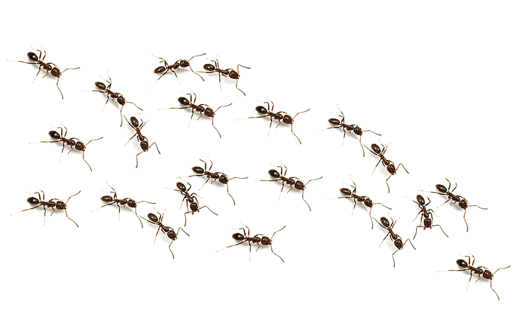

Here’s a table with the data collected: *(There’s way too much to take in, and it’s hard to visualize how the community composition varies from site to site. So this is here for your interest, but feel free to skip on over to the figures that summarize it all)*

|  | Site | Species | Abundance |
| --- | --- | --- | --- |
| 1 | 1.1.1 | Camponotus_sp.__.maculatus.group. | 0 |
| 2 | 1.1.1 | Crematogaster_sp.__1 | 7 |
| 3 | 1.1.1 | Crematogaster_sp.__2 | 0 |
| 4 | 1.1.1 | Crematogaster_sp.__3 | 0 |
| 5 | 1.1.1 | Lepisiota_sp.__1 | 7 |
| 6 | 1.1.1 | Leptothorax_sp.__1 | 0 |
| 7 | 1.1.1 | Monomorium_fridae | 0 |
| 8 | 1.1.1 | Monomorium_sp.__6 | 0 |
| 9 | 1.1.1 | Myrmicaria_nigra | 0 |
| 10 | 1.1.1 | Ocymyrmex_barbiger | 1 |

[output cut: 990 more lines]

It’s *much* easier to understand the data with the help of graphs:

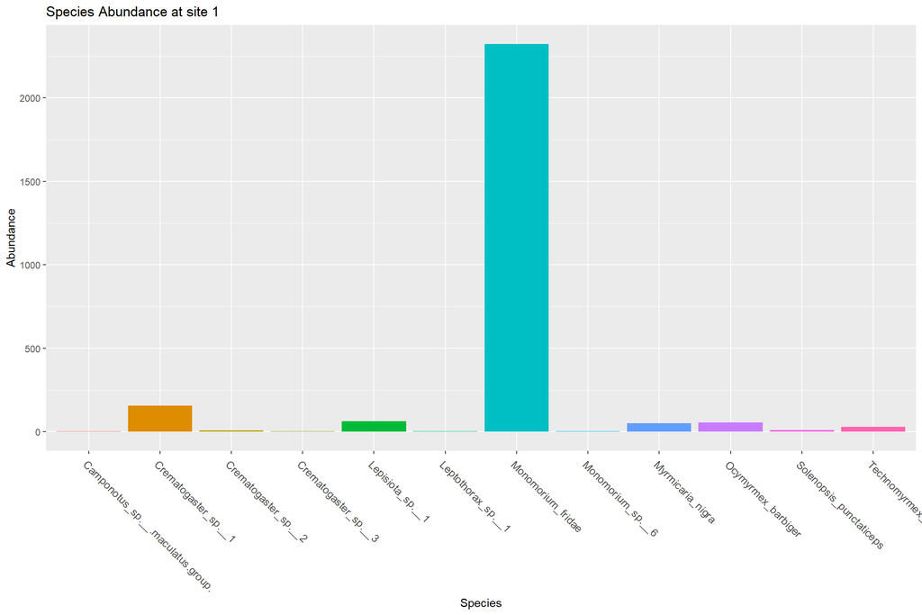

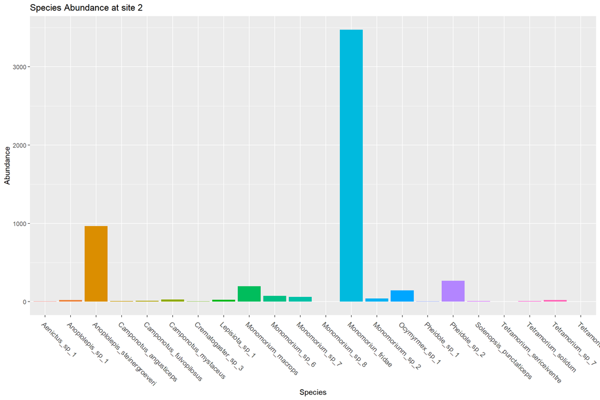

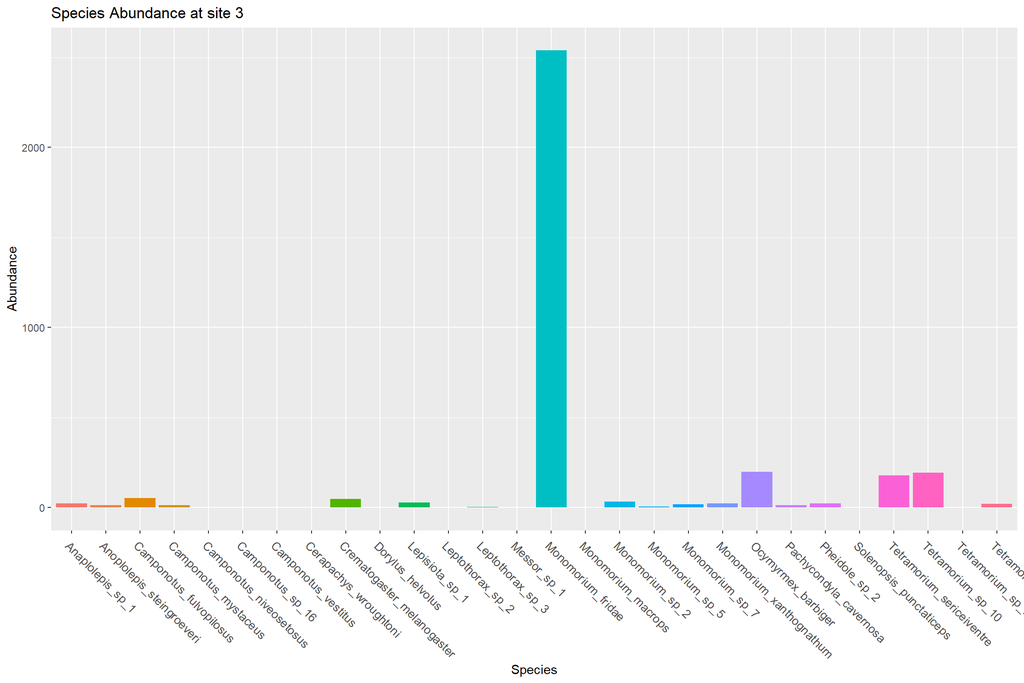

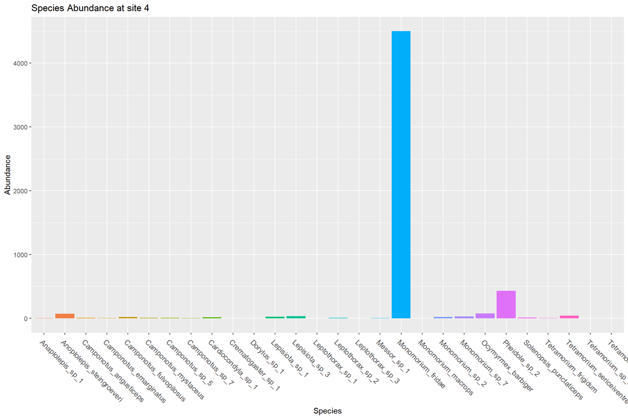

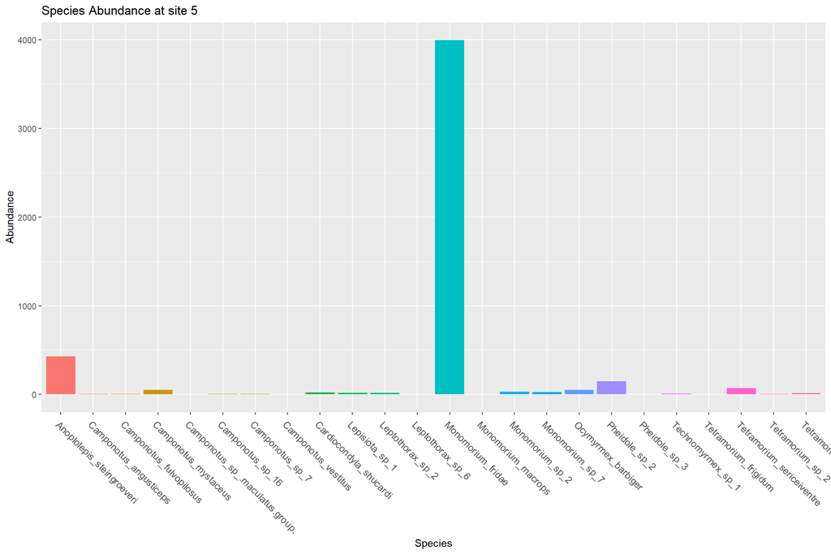

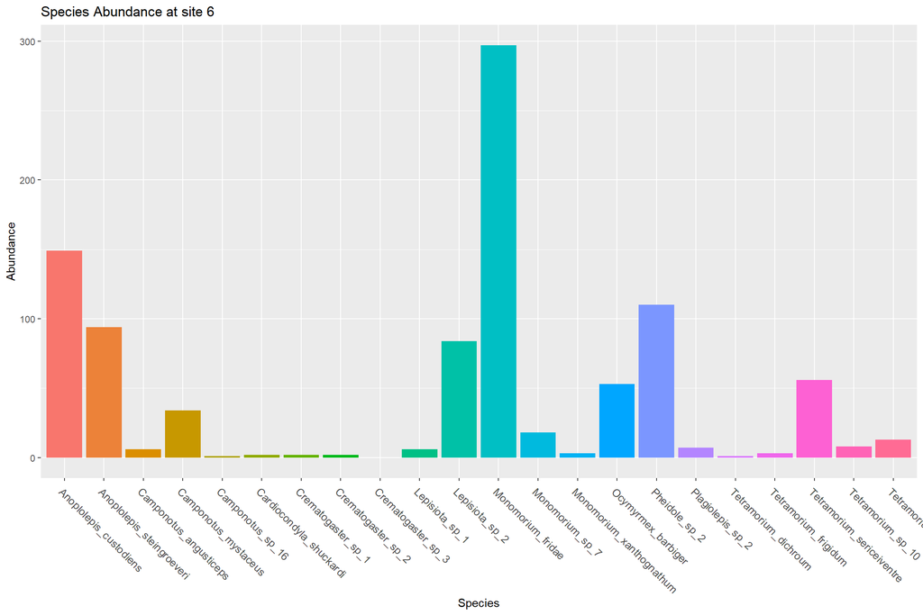

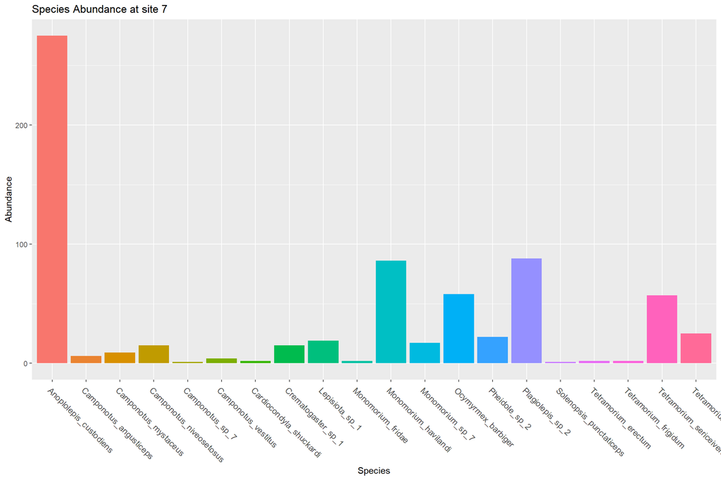

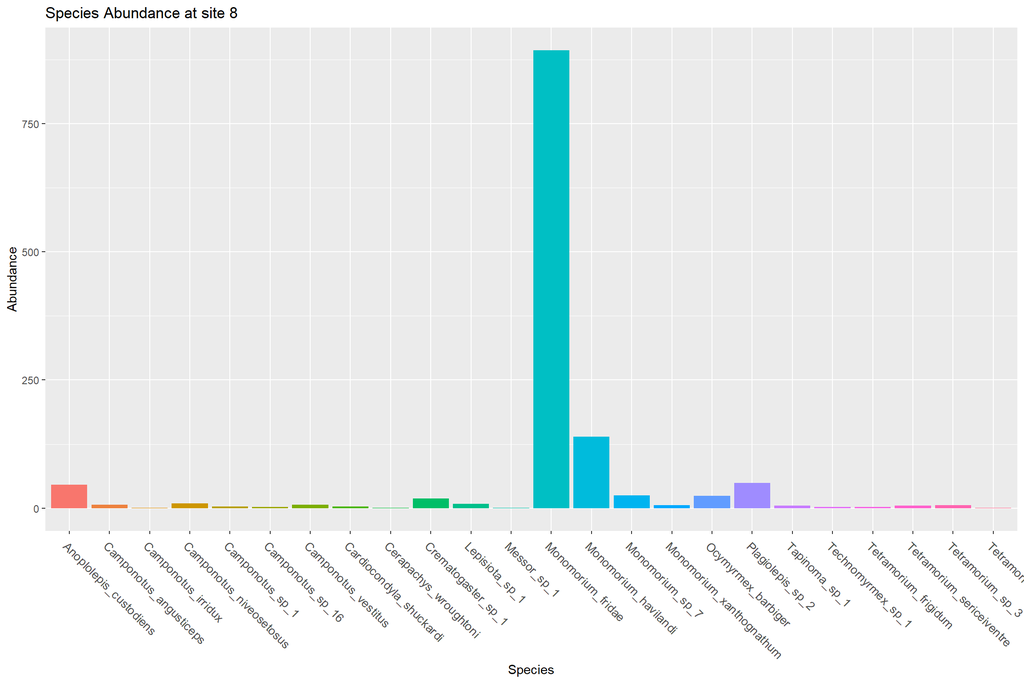

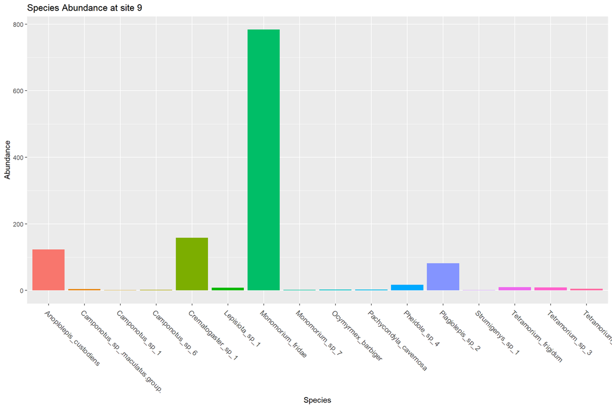

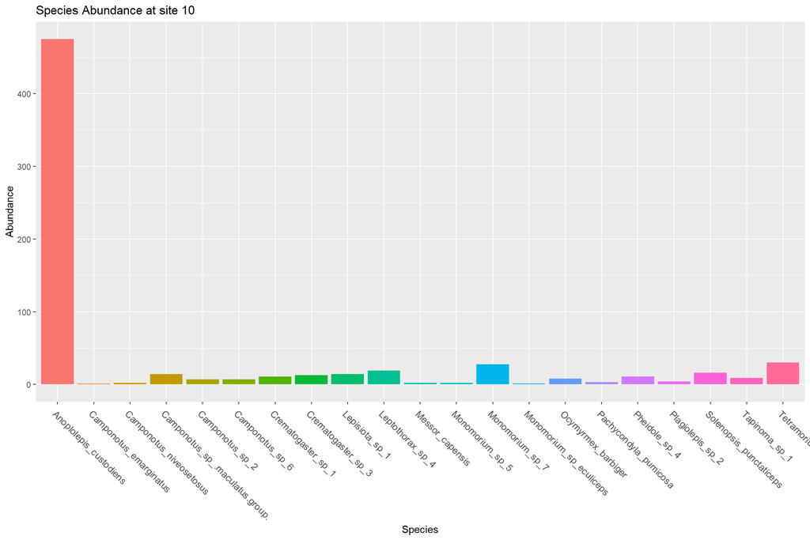

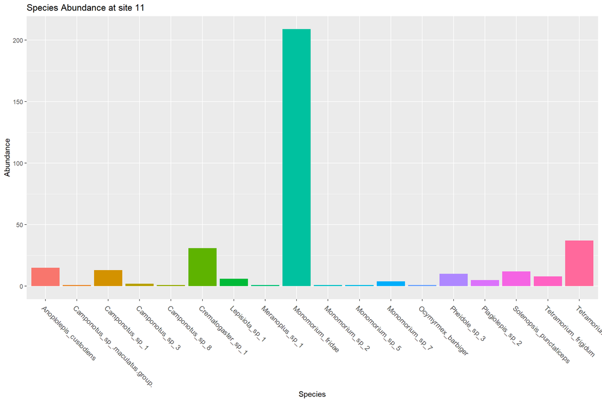

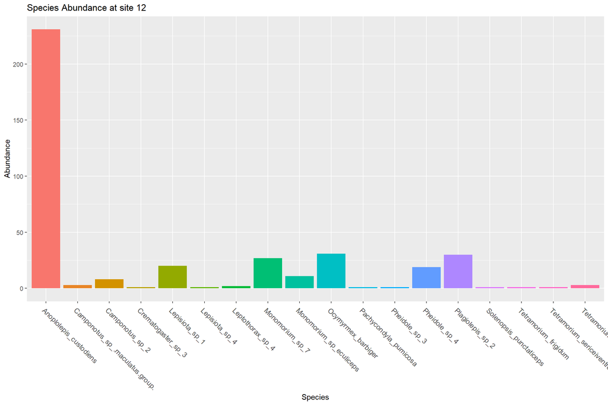

[5 more figures not shown]

If you’re curious about this project, check out the [Soil Ecology and Entomology Research Group](https://seer.org.za/).

Dr. Charlene Janion-Scheepers and Abusisiwe Ndaba (University of Cape Town) granted me access to this data for this project.

[figure not shown]